# Homework1

Alisha Gumber

9/17/2019

## Homework

```r
data(iris)
#View(iris)
```

0. Subset the Iris dataset to only include `Sepal.Length`, `Sepal.Width`, `Petal.Length`, and `Petal.Width`.

```r
iris_features = iris
iris_features$Species <- NULL
head(iris_features)
```

```
##   Sepal.Length Sepal.Width Petal.Length Petal.Width
## 1          5.1         3.5          1.4         0.2
## 2          4.9         3.0          1.4         0.2
## 3          4.7         3.2          1.3         0.2
## 4          4.6         3.1          1.5         0.2
## 5          5.0         3.6          1.4         0.2
## 6          5.4         3.9          1.7         0.4
```

1. Write out the Kmeans algorithm by hand, and run two iterations of it.

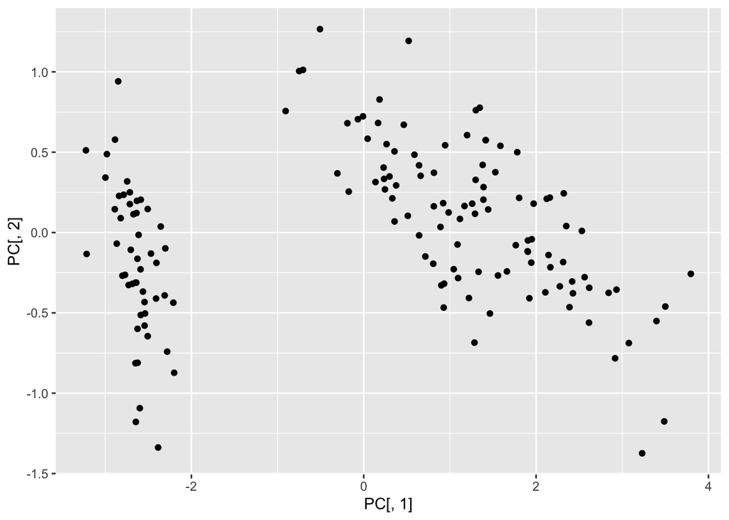

```r
# create PCA plot to use:
iris_clust_pca <- data.matrix(iris_features)
Center_iris <- apply(iris_clust_pca, 2, function(x) x - mean(x))
Covariance_iris <- cov(Center_iris)
Eigen_value_iris <- eigen(Covariance_iris)$value
Eigen_vector_iris <- eigen(Covariance_iris)$vector
PC <- as.data.frame(data.matrix(Center_iris) %*% Eigen_vector_iris)
ggplot(PC, aes(PC[,1], PC[,2],)) +
  geom_point(aes(PC[,1], PC[,2],))
```

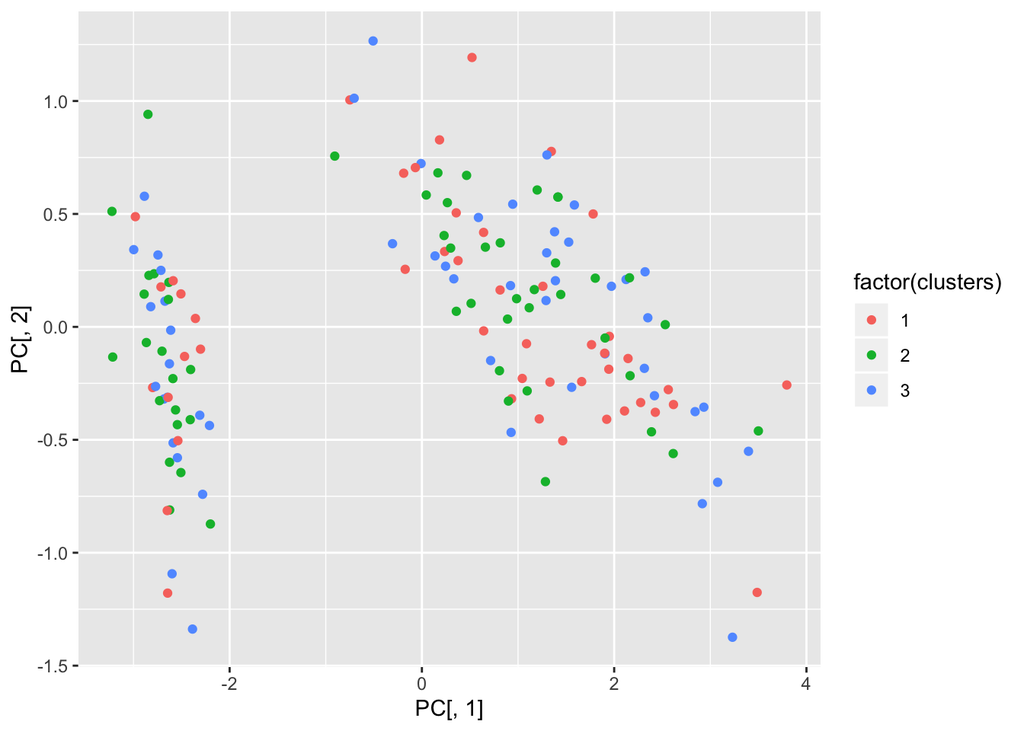

```r
# step 1: choose number of clusters (3) and randomly assign each point to a cluster
set.seed(10)
clusters <- sample(1:3, 150, replace=TRUE)
ggplot(PC, aes(PC[,1], PC[,2], color = factor(clusters))) +
  geom_point(aes(PC[,1], PC[,2],))
```

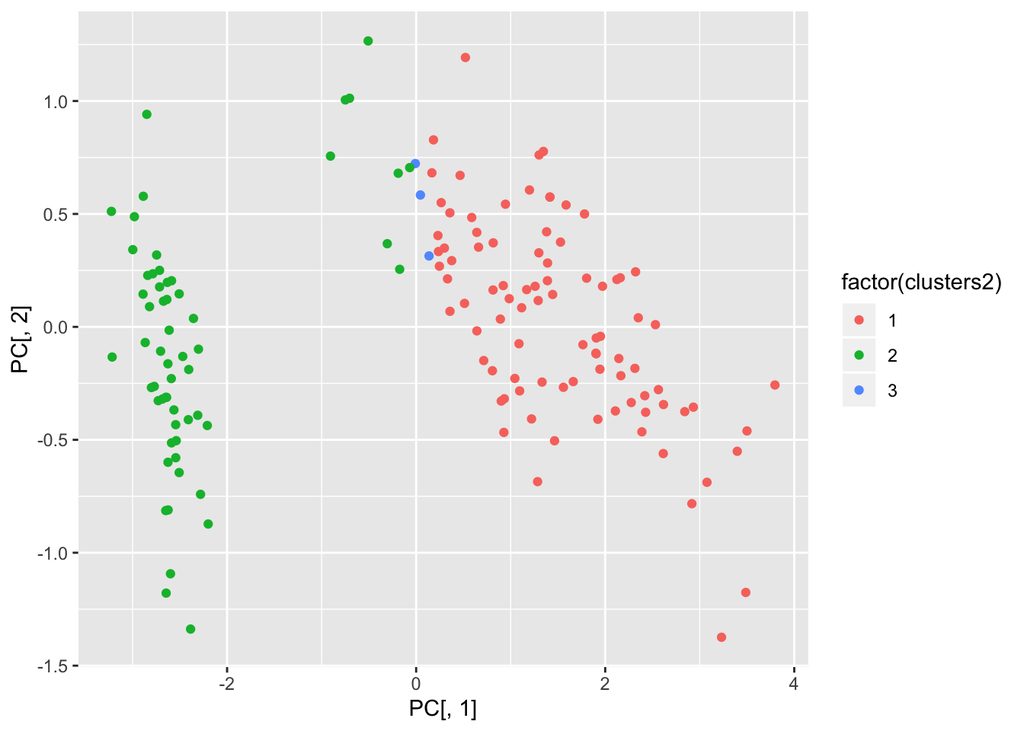

```r
# step 2: calculate centroid of each cluster (mean of each cluster)
# assign each cluster to specific points from random sample 1, 2, and 3
clust1 <- iris_features[which(clusters==1),]
clust2 <- iris_features[which(clusters==2),]
clust3 <- iris_features[which(clusters==3),]

# calculate centroids of each cluster using colMeans function (takes mean of the columns)
centroid1 <- colMeans(clust1)
centroid2 <- colMeans(clust2)
centroid3 <- colMeans(clust3)

# step 3: calculate the distance from each point to centroid
# create euclidean distance function to find distance of each point to cluster centroid
euclidean_distance <- function(x1, x2){
  sum((x1-x2)^2)
}
dist_centroid1 <- apply(iris_features, 1, function(x){
  euclidean_distance(x, centroid1)
})
dist_centroid2 <- apply(iris_features, 1, function(x){
  euclidean_distance(x, centroid2)
})
dist_centroid3 <- apply(iris_features, 1, function(x){
  euclidean_distance(x, centroid3)
})
dist_matrix <- cbind(dist_centroid1, dist_centroid2, dist_centroid3)

clusters2 <- apply(dist_matrix, 1, which.min)

# plot new clusters
ggplot(PC, aes(PC[,1], PC[,2], color = factor(clusters2))) +
  geom_point(aes(PC[,1], PC[,2],))
```

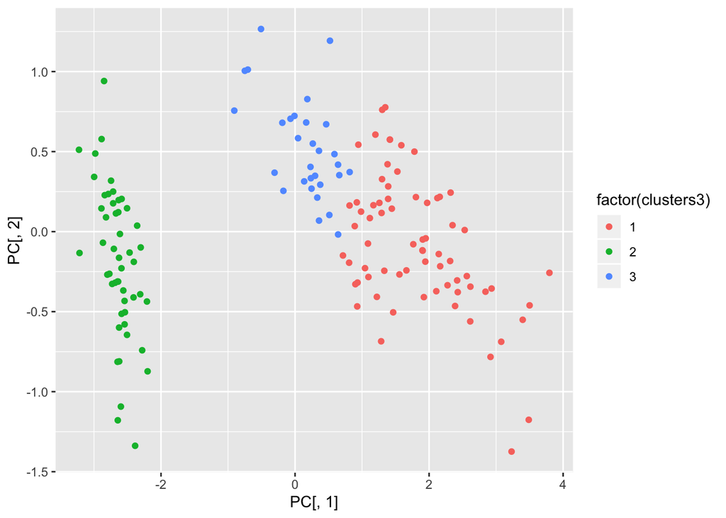

```r
# second iteration: run steps 2 and 3 again
# assign (new) clusters to points
clust1.2 <- iris_features[which(clusters2==1),]
clust2.2 <- iris_features[which(clusters2==2),]
clust3.2 <- iris_features[which(clusters2==3),]
# calculate new centroids of clusters
centroid1.2 <- colMeans(clust1.2)
centroid2.2 <- colMeans(clust2.2)
centroid3.2 <- colMeans(clust3.2)

# use euclidean distance function to
euclidean_distance <- function(x1, x2){
  sum((x1-x2)^2)
}
dist_centroid1.2 <- apply(iris_features, 1, function(x){
  euclidean_distance(x, centroid1.2)
})
dist_centroid2.2 <- apply(iris_features, 1, function(x){
  euclidean_distance(x, centroid2.2)
})
dist_centroid3.2 <- apply(iris_features, 1, function(x){
  euclidean_distance(x, centroid3.2)
})

dist_matrix2 <- cbind(dist_centroid1.2, dist_centroid2.2, dist_centroid3.2)

clusters3 <- apply(dist_matrix2, 1, which.min)

# plot 2nd iteration of k-means with 3 clusters
ggplot(PC, aes(PC[,1], PC[,2], color = factor(clusters3))) +
  geom_point(aes(PC[,1], PC[,2],))
```

2. Run PCA on the Iris dataset. Plot a scatter plot of PC1 vs PC2 and include the percent variance those PCs describe.

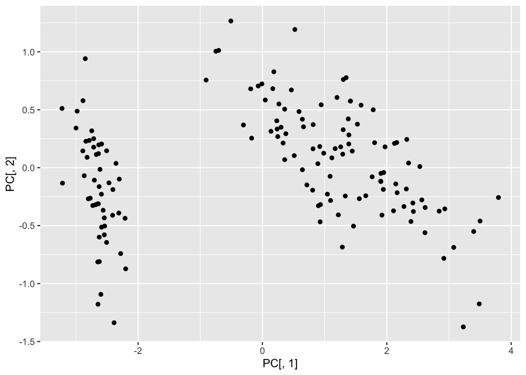

```r
# center the data by subtracting the mean of the each column from the values in that column
iris_clust_pca <- data.matrix(iris_features)
Center_iris <- apply(iris_clust_pca, 2, function(x) x - mean(x))

# calculate covariance matrix
Covariance_iris <- cov(Center_iris)

# calculate eigen values and vector
Eigen_value_iris <- eigen(Covariance_iris)$value

#columns are the eigen vectors
Eigen_vector_iris <- eigen(Covariance_iris)$vector

# multiply eigen vector matrix by original the original data
PC <- as.data.frame(data.matrix(Center_iris) %*% Eigen_vector_iris)

ggplot(PC, aes(PC[,1], PC[,2])) +
  geom_point(aes(PC[,1], PC[,2],))
```

```r
# to find the percent variance each PC describe, for each component, take the cumulative sum of eigen values up to that point and and divide by the total sum of eigen values
round(cumsum(Eigen_value_iris)/sum(Eigen_value_iris) * 100, digits = 2)
```

```
## [1]  92.46  97.77  99.48 100.00
```

**Principal component 1 explains 92.46% of the variance, PC 1 and 2 explain 97.77% of the variance. PC 1, 2, and 3 together explain 99.48% of the variance, and PC 1, 2, 3, and 4 together explain 100% of the variance in the data.**

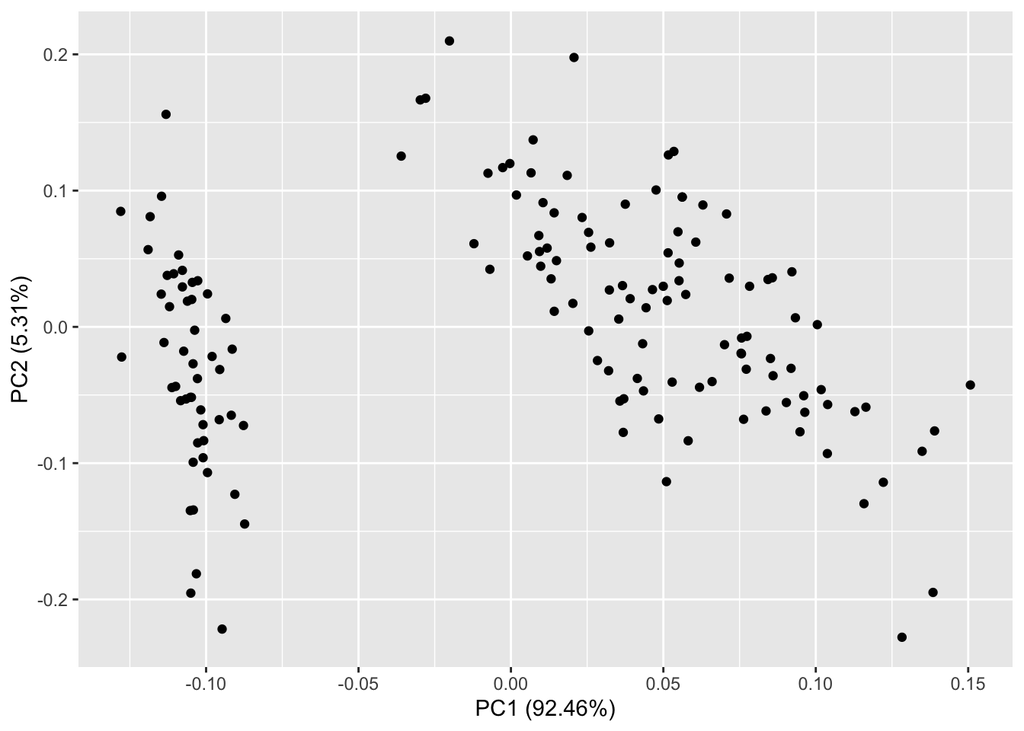

```r
# run PCA just using the prcomp function
autoplot(prcomp(iris_clust_pca,))
```

3. Run ICA on the Iris dataset. Plot the independent components as a heatmap.

```r
# ICA on iris data
A <- fastICA(iris_features, 4, alg.typ = "parallel", fun = "logcosh", alpha = 1,
             method = "R", row.norm = FALSE, maxit = 200,
             tol = 0.0001, verbose = TRUE)
```

```
## Centering
```

```
## Whitening
```

```
## Symmetric FastICA using logcosh approx. to neg-entropy function
```

```
## Iteration 1 tol = 0.8183822
```

```
## Iteration 2 tol = 0.1783042
```

```
## Iteration 3 tol = 0.9711491
```

```
## Iteration 4 tol = 0.1566586
```

```
## Iteration 5 tol = 0.03298397
```

```
## Iteration 6 tol = 0.01155871
```

```
## Iteration 7 tol = 0.005267728
```

```
## Iteration 8 tol = 0.002702729
```

```
## Iteration 9 tol = 0.001803739
```

```
## Iteration 10 tol = 0.001118269
```

```
## Iteration 11 tol = 0.0006931437
```

```
## Iteration 12 tol = 0.0004294483
```

```
## Iteration 13 tol = 0.000261528
```

```
## Iteration 14 tol = 0.0001612551
```

```
## Iteration 15 tol = 9.798808e-05
```

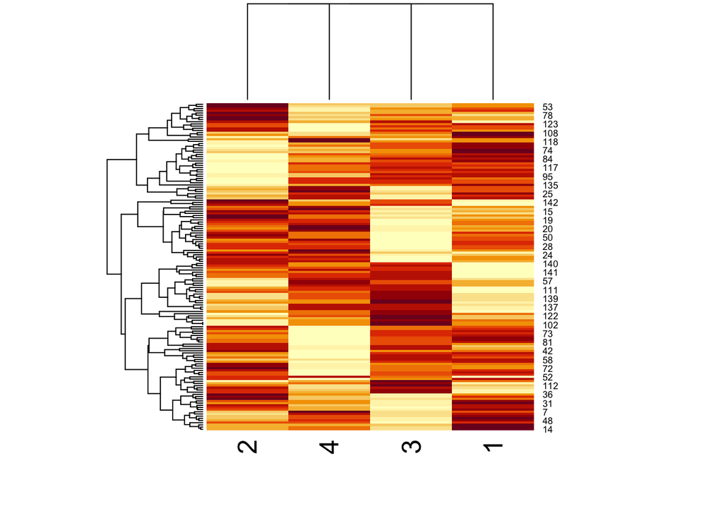

```r
heatmap(A$S)
```

4. Use Kmeans to cluster the Iris data.
- Use the silhouette function in the cluster package to find the optimal number of clusters for kmeans for the iris dataset. Then cluster using kmeans clustering. Does the data cluster by species?
- Using this clustering, color the PCA plot according to the clusters.

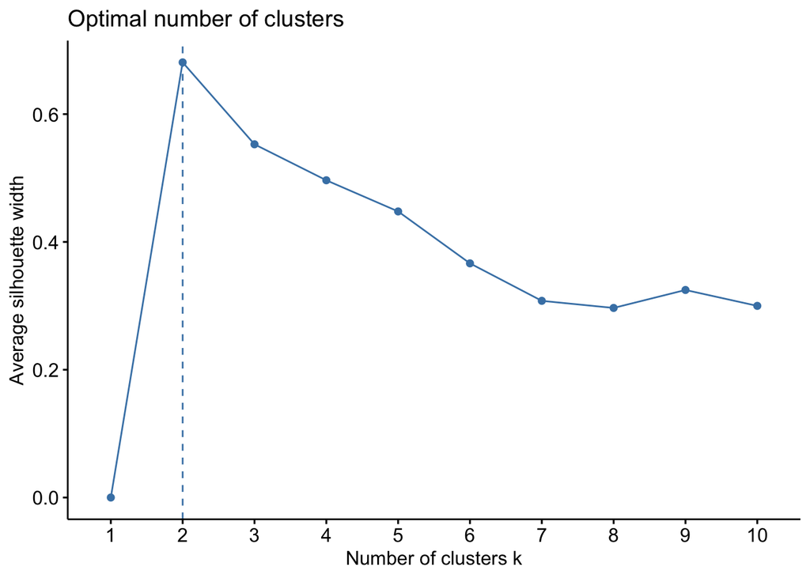

```r
# use fviz_nbclust function to find optimal number of kmeans clusters using silhouette method
sil <- fviz_nbclust(iris_features, kmeans, method='silhouette')
sil
```

**The data does not cluster by species. There are 3 species listed in the original data set, but silhouette analysis determines the optimal clusters should only be 2.**

```r
# use optimal number of clusters = 2 from silhouette analysis for k-means
kmeans_result <- kmeans(iris_features, 2)
str(kmeans_result)
```

```
## List of 9
##  $ cluster     : int [1:150] 1 1 1 1 1 1 1 1 1 1 ...
##  $ centers     : num [1:2, 1:4] 5.01 6.3 3.37 2.89 1.56 ...
##   ..- attr(*, "dimnames")=List of 2
##   .. ..$ : chr [1:2] "1" "2"
##   .. ..$ : chr [1:4] "Sepal.Length" "Sepal.Width" "Petal.Length" "Petal.Width"
##  $ totss       : num 681
##  $ withinss    : num [1:2] 28.6 123.8
##  $ tot.withinss: num 152
##  $ betweenss   : num 529
##  $ size        : int [1:2] 53 97
##  $ iter        : int 1
##  $ ifault      : int 0
##  - attr(*, "class")= chr "kmeans"
```

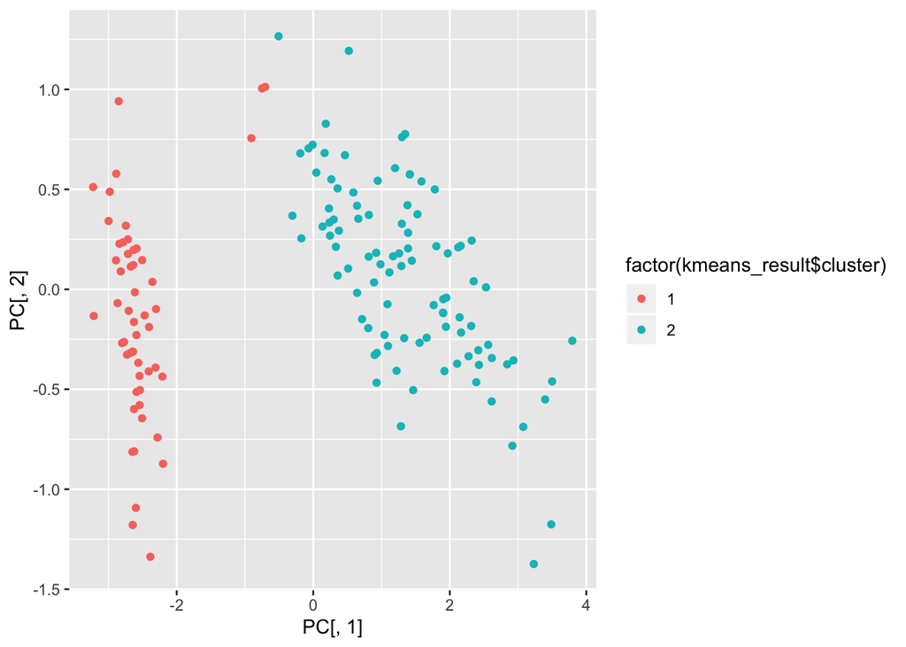

```r
# color PCA plot according to clusters:
ggplot(PC, aes(PC[,1], PC[,2], color = factor(kmeans_result$cluster))) +
  geom_point(aes(PC[,1], PC[,2],))
```

5. Use hierarchical clustering to cluster the Iris data.
- Try two different linkage types, and two different distance metrics.
- For one linkage type and one distance metric, try two different cut points.
- Using this clustering, color the PCA plot according to the clusters. (6 plots in total)

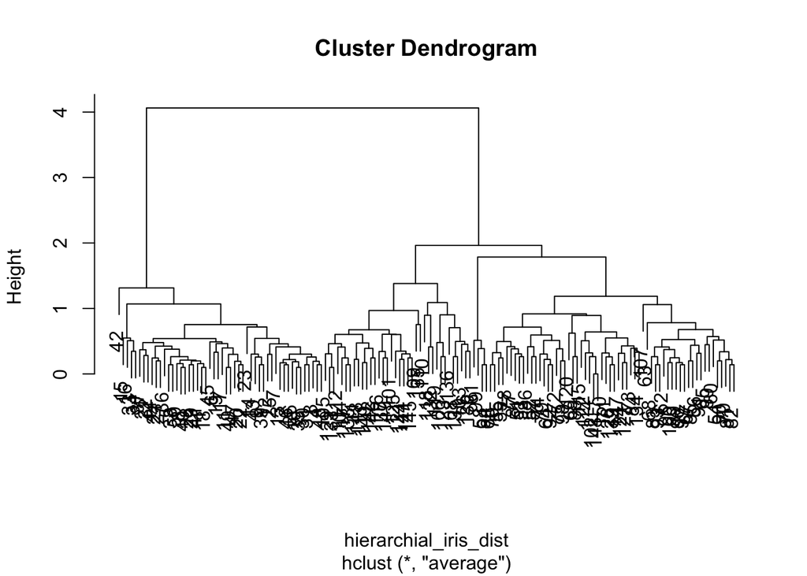

```r
# method 1: distance = euclidean and linkage = average
hierarchial_iris_dist <- dist(iris_features, method="euclidean")
iris_tree <- hclust(hierarchial_iris_dist, method="average")
plot(iris_tree)
```

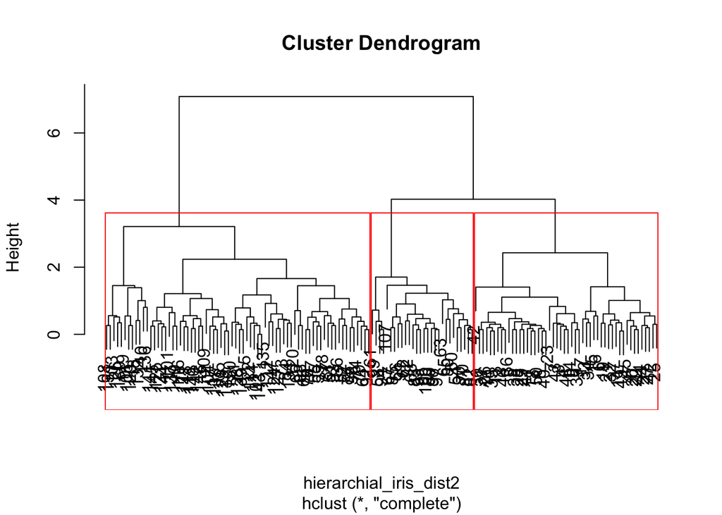

```r
# method 2: distance = euclidean and linkage = complete
hierarchial_iris_dist2 <- dist(iris_features, method="euclidean")
iris_tree2 <- hclust(hierarchial_iris_dist2, method="complete")
plot(iris_tree2)

# one cut point for method 2: distance = euclidean and linkage = complete
plot(iris_tree2)
tree_k <- cutree(iris_tree2, k=3)
rect.hclust(iris_tree2, k=3, h=NULL)
```

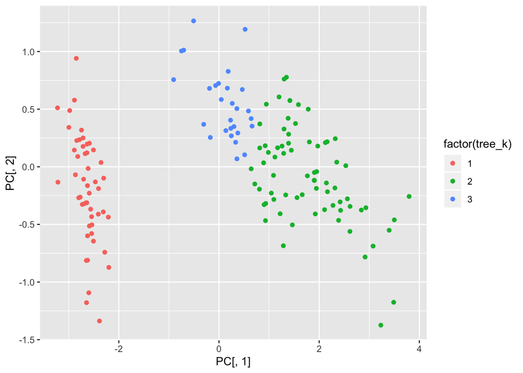

```r
# color PCA plot according to 4 clusters:
ggplot(PC, aes(PC[,1], PC[,2], color = factor(tree_k))) +
  geom_point(aes(PC[,1], PC[,2],))
```

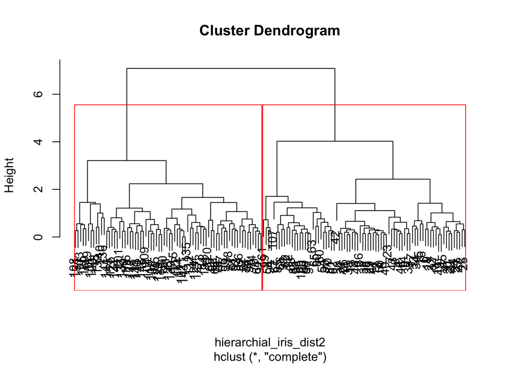

```r
# another cut point for method 2
plot(iris_tree2)
tree_k2 <- cutree(iris_tree2, k=2)
rect.hclust(iris_tree2, k=2, h=NULL)
```

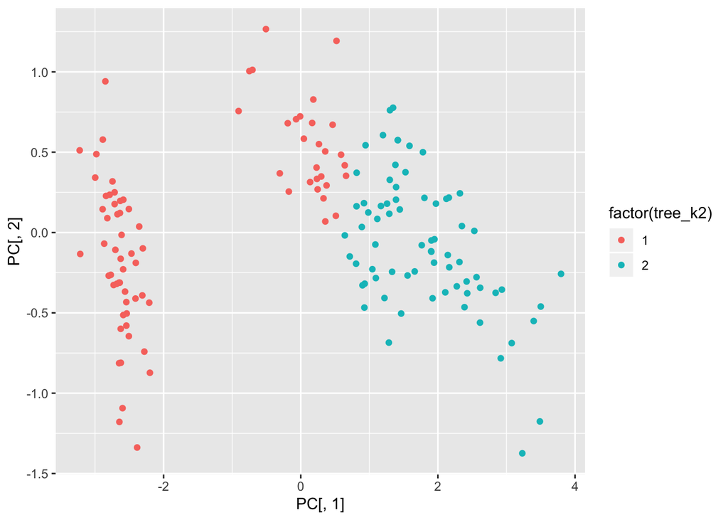

```r
# color PCA plot according to 2 cluster
ggplot(PC, aes(PC[,1], PC[,2], color = factor(tree_k2))) +
  geom_point(aes(PC[,1], PC[,2],))
```

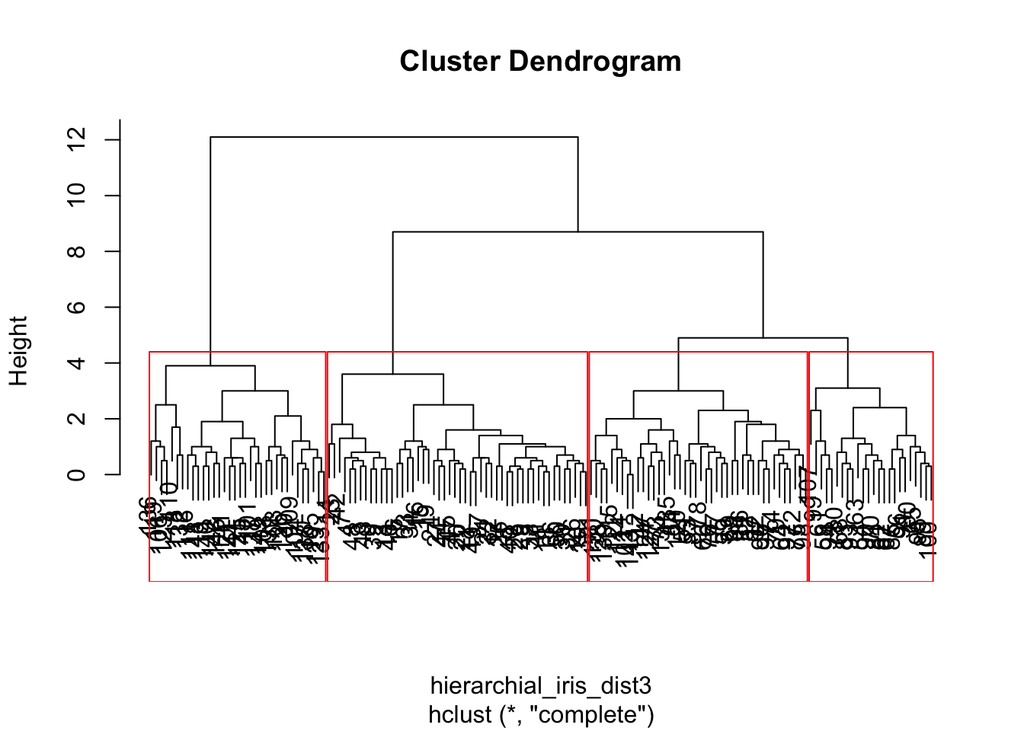

```r
# method 3: distance = manhattan and linkage = complete
hierarchial_iris_dist3 <- dist(iris_features, method="manhattan")
iris_tree3 <- hclust(hierarchial_iris_dist3, method="complete")
plot(iris_tree3)

# one cut point for method 3: distance = manhattan and linkage = complete
plot(iris_tree3)
tree_k4 <- cutree(iris_tree3, k=4)
rect.hclust(iris_tree3, k=4, h=NULL)
```

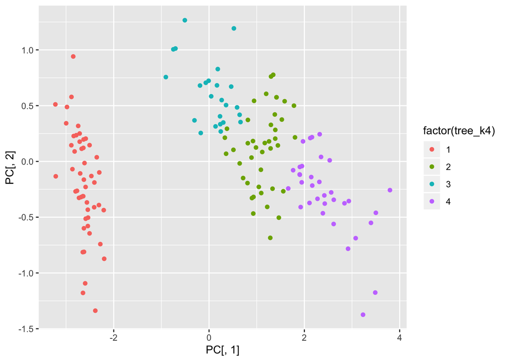

```r
# color PCA plot according to 4 clusters:
ggplot(PC, aes(PC[,1], PC[,2], color = factor(tree_k4))) +
  geom_point(aes(PC[,1], PC[,2],))
```

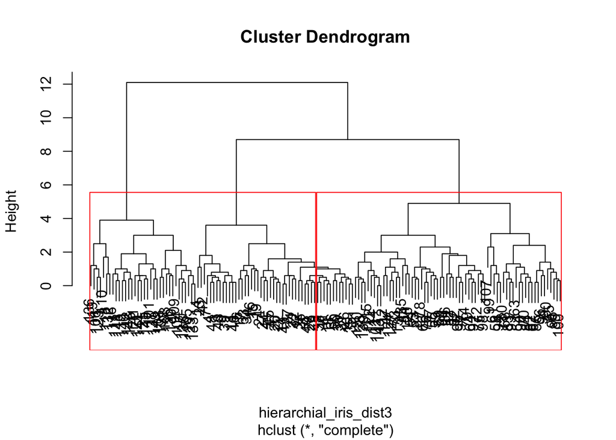

```r
# another cut point for method 2
plot(iris_tree3)
tree_k2 <- cutree(iris_tree3, k=2)
rect.hclust(iris_tree2, k=2, h=NULL)
```

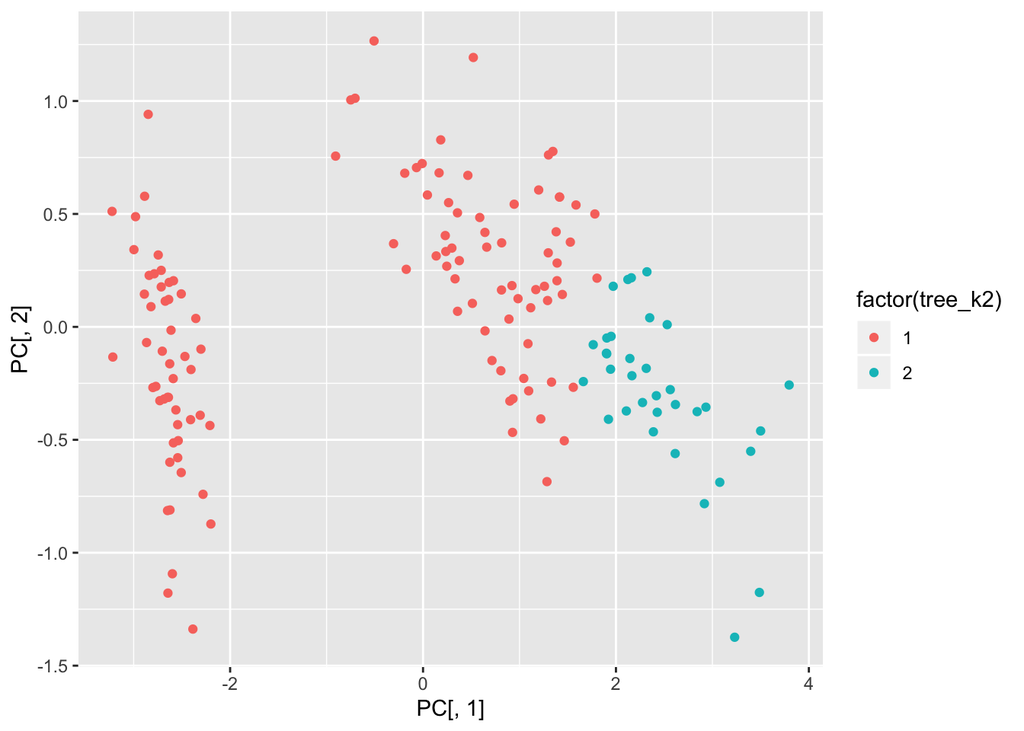

```r
# color PCA plot according to 2 cluster
ggplot(PC, aes(PC[,1], PC[,2], color = factor(tree_k2))) +
  geom_point(aes(PC[,1], PC[,2],))
```

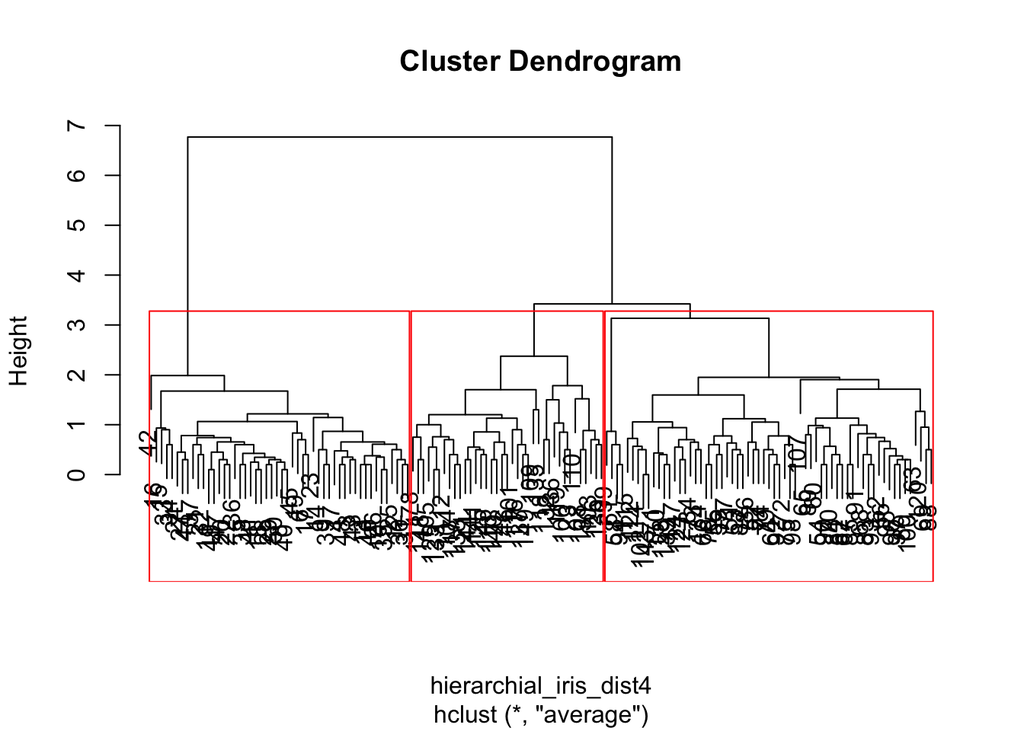

```r
# method 4: distance = manhattan and linkage = average
hierarchial_iris_dist4 <- dist(iris_features, method="manhattan")
iris_tree4 <- hclust(hierarchial_iris_dist4, method="average")
plot(iris_tree4)

# one cut point for method 4: distance = manhattan and linkage = average
plot(iris_tree4)
tree_k3 <- cutree(iris_tree4, k=3)
rect.hclust(iris_tree4, k=3, h=NULL)
```

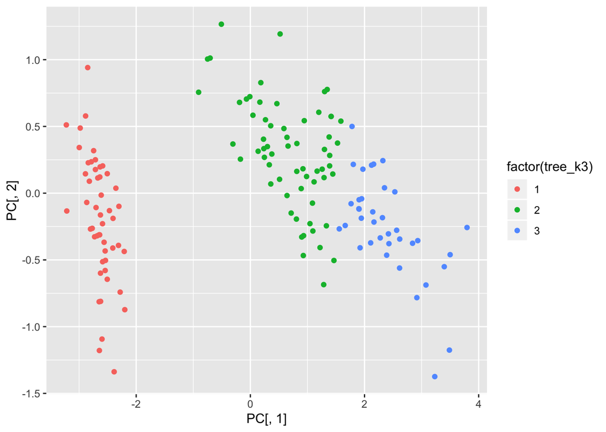

```r
# color PCA plot according to 3 clusters:
ggplot(PC, aes(PC[,1], PC[,2], color = factor(tree_k3))) +
  geom_point(aes(PC[,1], PC[,2],))
```

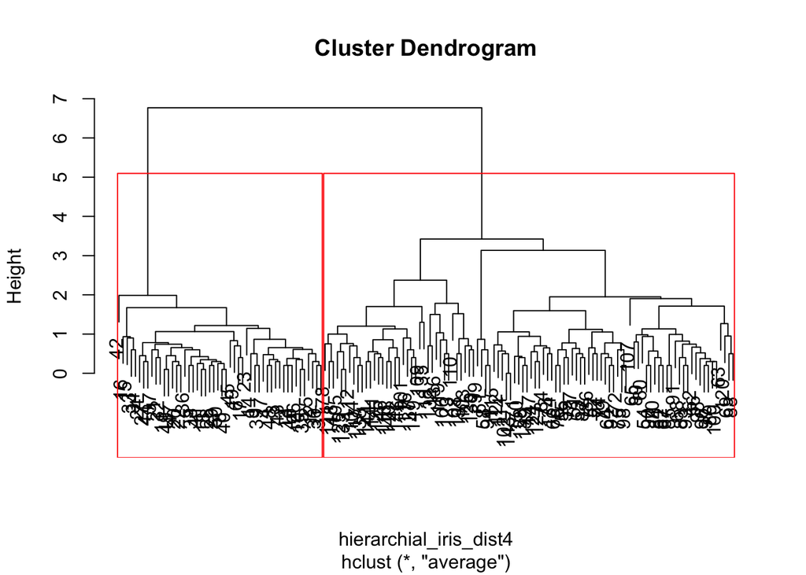

```r
# another cut point for method 4
plot(iris_tree4)
tree_k2 <- cutree(iris_tree4, k=2)
rect.hclust(iris_tree4, k=2, h=NULL)
```

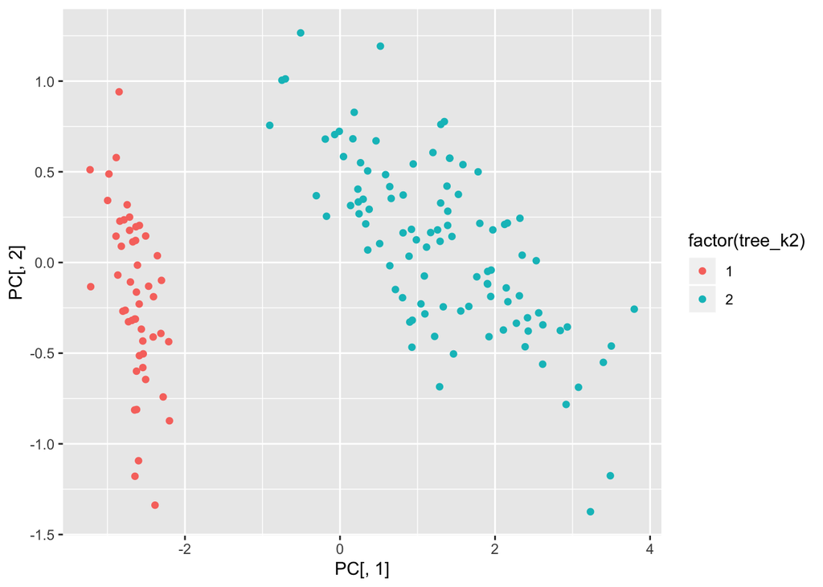

```r
# color PCA plot according to 2 cluster
ggplot(PC, aes(PC[,1], PC[,2], color = factor(tree_k2))) +
  geom_point(aes(PC[,1], PC[,2],))
```

# Optional material

On PCA:

Eigen Vectors and Eigen Values http://www.visiondummy.com/2014/03/eigenvalues-eigenvectors/ Linear Algebra by Prof. Gilbert Strang https://ocw.mit.edu/courses/mathematics/18-06-linear-algebra-spring-2010/video-lectures/ http://www.cs.otago.ac.nz/cosc453/student_tutorials/principal_components.pdf https://stats.stackexchange.com/questions/2691/making-sense-of-principal-component-analysis-eigenvectors-eigenvalues

On ICA:

Independent Component Analysis: Algorithms and Applications https://www.cs.helsinki.fi/u/ahyvarin/papers/NN00new.pdf Tutorial on ICA taken from http://rstudio-pubs-static.s3.amazonaws.com/93614_be30df613b2a4707b3e5a1a62f631d19.html